# homework8

##### 1.Proof:

Let $A=(\alpha_1,\alpha_2,\cdots,\alpha_k),\ \Lambda=\text{diag}\{\lambda_1,\lambda_2,\cdots,\lambda_m\}$, we have $$\Sigma=A\Lambda A^T=\begin{bmatrix} \sum_{i=1}^m \lambda_i\alpha_{1i}^2 & / & \cdots & / \\ / & \sum_{i=1}^m \lambda_i\alpha_{2i}^2 & \cdots & / \\ \vdots & \vdots & \ddots & \vdots\\ / & / & \cdots & \sum_{i=1}^m \lambda_i\alpha_{mi}^2 \end{bmatrix} $$ i.e. $\sigma_{ii}=\text{Var}(X_i)=\sum_{k=1}^m\lambda_k\alpha_{ik}^2$.
Thus, $\sum_{k}\rho^2(Y_k,X_i)=\sum_{k}\frac{\lambda_k\alpha_{ik}^2}{\sigma_{ii}}=1$.

##### 2.Solution:

Step1: $G_i=\{x_i\},i=1,2,3,4,5$  
Step2: Due to $D_{13}=D_{31}=1$ is minimum, so combine $x_1$ and $x_3$ to $G_6=\{x_1, x_3\}$  
Step3: $D_{62}=5,D_{64}=8,D_{65}=2,D_{24}=4,D_{25}=6,D_{45}=5$, so combine $G_6$ and $G_5$ to $G_7=\{x_1,x_3,x_5\}$  
Step4: $D_{72}=5,D_{74}=5,D_{24}=4$, so combine $G_2$ and $G_4$ to $G_8=\{x_2,x_4\}$  
Step5: Combine $G_7$ and $G_8$ to $G_9=\{x_1,x_2,x_3,x_4,x_5\}$, over.

##### 3.Proof:

主成分分析即取前$k$个奇异值对应的特征向量，等价于求前$k$个奇异值分解.  
对$X$进行奇异值分解，设$A=U\Sigma V^T$，由Frobenius范数的性质得$||X-L||_F=||U(\Sigma-U^TLV)V^T||_F=||\Sigma-M||_F(M=U^TLV)=\sum_{i=1}^{\text{min}(m,n)}(\sigma_{ii}-m_{ii})^2+\sum_{i\ne j}m_{ij}^2$  
要找到$L^{*}$使得上式最小且满足约束条件$\text{rank}(L)\leqslant k$，则必有$m_{ij}=0,m_{ii}=\sigma_{ii}(1\leqslant i\leqslant\ k)$  
即有$\Sigma=U^TL^{*}V\Rightarrow L^{*}=U_k\Sigma_k V_k^T$  
故在约束条件$\text{rank}(L)\leqslant k$下求$L$使得$||X-L||_F$最小等价于主成分分析.  
I don't know how to use the hint.

```python
''''(1)'''
import pandas as pd
import numpy as np
import matplotlib.pyplot as plt
from sklearn.preprocessing import StandardScaler
from sklearn.decomposition import PCA
from sklearn.cluster import KMeans

nba = pd.read_excel("NBA.xlsx")
```

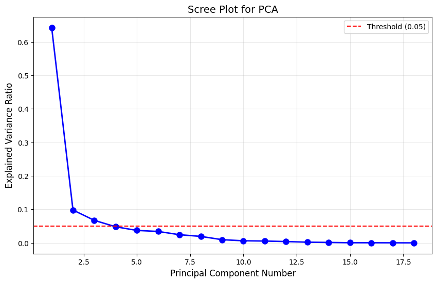

```python
''''(2)'''
numeric_columns = nba.select_dtypes(include=[np.number]).columns
nba_numeric = nba[numeric_columns].copy()

scaler = StandardScaler()
nba_scaled = scaler.fit_transform(nba_numeric)

pca = PCA()
pca_result = pca.fit_transform(nba_scaled)

explained_variance_ratio = pca.explained_variance_ratio_
cumulative_variance = np.cumsum(explained_variance_ratio)


plt.figure(figsize=(10, 6))
plt.plot(range(1, len(explained_variance_ratio)+1),
         explained_variance_ratio,
         'bo-',
         linewidth=2,
         markersize=8)
plt.title('Scree Plot for PCA', fontsize=14)
plt.xlabel('Principal Component Number', fontsize=12)
plt.ylabel('Explained Variance Ratio', fontsize=12)
plt.axhline(y=0.05, color='r', linestyle='--', label='Threshold (0.05)')
plt.grid(True, alpha=0.3)
plt.legend()
plt.show()
```

由图可知选择4个左右的主成分最优。

```python
''''(3)'''
pc_cols = [f"PC{i+1}" for i in range(len(explained_variance_ratio))]
pc_scores = pd.DataFrame(pca_result, columns=pc_cols)

if "球员" in nba.columns:
    pc_scores["球员"] = nba["球员"].values

print("\n前10个球员的主成分得分:")
print(pc_scores[["球员", "PC1", "PC2", "PC3"]].head(10))

if "球员" in pc_scores.columns:
    top3_pc1 = pc_scores.nlargest(3, "PC1")[["球员", "PC1"]]
    bottom3_pc1 = pc_scores.nsmallest(3, "PC1")[["球员", "PC1"]]

    print("\nPC1得分最高的3位球员:")
    print(top3_pc1)
    print("\nPC1得分最低的3位球员:")
    print(bottom3_pc1)

loadings = pd.DataFrame(
    pca.components_.T,
    columns=pc_cols,
    index=numeric_columns
)
print("\n前3个主成分的载荷矩阵:")
print(loadings[["PC1", "PC2", "PC3"]].round(3))
```

```
前10个球员的主成分得分:
        球员        PC1        PC2       PC3
0  勒布朗-詹姆斯  36.103443   4.518744 -5.682474
1   迈克尔-乔丹  26.481330  -0.799841 -2.520520
2  卡里姆-贾巴尔  20.235283  -9.044961  0.589844
3  科比-布莱恩特  27.978097   3.801736 -4.116818
4  沙奎尔-奥尼尔  25.654499 -10.336553  0.598746
5    蒂姆-邓肯  27.078136  -9.858445  1.049834
6    卡尔-马龙  22.501791  -6.220351 -0.461917
7   杰里-韦斯特  15.317417  -6.350493 -0.413197
8    托尼-帕克  19.303320   1.241080 -2.212747
9   凯文-杜兰特  19.049409   4.699089 -2.912801

PC1得分最高的3位球员:
        球员        PC1
0  勒布朗-詹姆斯  36.103443
3  科比-布莱恩特  27.978097
5    蒂姆-邓肯  27.078136

PC1得分最低的3位球员:
                球员      PC1
2339         厄尔-巴隆 -2.26126
2346        埃里克-墨菲 -2.26126
2299  Fatty0Taylor -2.26102

前3个主成分的载荷矩阵:
              PC1    PC2    PC3
出场数         0.270 -0.028  0.080
上场总时间（min）  0.286 -0.044  0.009
投篮率         0.056  0.045  0.720
命中次数        0.283 -0.118 -0.016
出手次数        0.283 -0.092 -0.031
三分投球率       0.061  0.471  0.330
三分命中次数      0.188  0.513 -0.188
三分出手次数      0.195  0.503 -0.193
罚球率         0.082  0.122  0.500
罚球命中次数      0.275 -0.132 -0.041
罚球出手次数      0.274 -0.175 -0.027
篮板数         0.247 -0.252  0.067
助攻次数        0.254  0.036 -0.099
抢断次数        0.253  0.174 -0.080
盖帽次数        0.196 -0.181  0.092
失误次数        0.257  0.134 -0.074
犯规次数        0.269 -0.134  0.071
生涯总得分       0.285 -0.088 -0.033
```

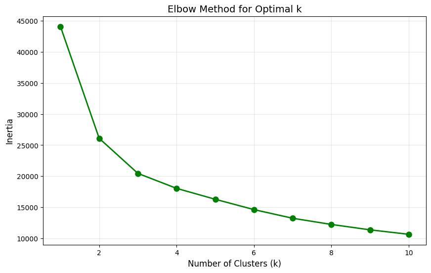

```
各聚类的球员数量:
Cluster
0    1991
1     398
2      59
Name: count, dtype: int64

各聚类的数值特征均值:
             出场数  上场总时间（min）    投篮率      命中次数      出手次数  三分投球率   三分命中次数  \
Cluster
0         16.684     259.762  0.387    39.559    93.752  0.116    3.666
1         78.118    2088.809  0.449   331.930   742.246  0.190   32.153
2        163.102    5938.864  0.468  1136.068  2410.373  0.262  125.271

          三分出手次数    罚球率   罚球命中次数   罚球出手次数       篮板数     助攻次数     抢断次数  \
Cluster
0         10.839  0.586   21.685   30.018    46.255   22.493    6.042
1         92.776  0.751  186.111  247.854   389.774  181.427   50.108
2        354.763  0.783  700.576  914.271  1164.525  726.898  186.136

            盖帽次数     失误次数     犯规次数     生涯总得分
Cluster
0          3.944    9.427   34.321   104.525
1         36.226   83.307  212.867   882.482
2        118.966  338.051  469.085  3098.610
```

```python
"""(4)"""
inertia_list = []
k_range = range(1, 11)
for k in k_range:
    kmeans = KMeans(n_clusters=k, random_state=42, n_init=10)
    kmeans.fit(nba_scaled)
    inertia_list.append(kmeans.inertia_)

plt.figure(figsize=(10, 6))
plt.plot(k_range, inertia_list, 'go-', linewidth=2, markersize=8)
plt.title('Elbow Method for Optimal k', fontsize=14)
plt.xlabel('Number of Clusters (k)', fontsize=12)
plt.ylabel('Inertia', fontsize=12)
plt.grid(True, alpha=0.3)
plt.show()

optimal_k = 3
kmeans = KMeans(n_clusters=optimal_k, random_state=42, n_init=10)
nba["Cluster"] = kmeans.fit_predict(nba_scaled)

print("\n各聚类的球员数量:")
print(nba["Cluster"].value_counts())

print("\n各聚类的数值特征均值:")
cluster_means = nba.groupby("Cluster")[numeric_columns].mean().round(3)
print(cluster_means)

if "Name" in nba.columns:
    cluster_players = nba.groupby("Cluster")["Name"].apply(list)
    print("\n各聚类的球员名单:")
    for cluster, players in cluster_players.items():
        print(f"聚类 {cluster}: {players[:5]}...")
```